[figure not shown]

# 3er Semana - Analsis Matemático - Aplicación de funciones en ML

https://es.wikipedia.org/wiki/Función_matemática

En matemática, se dice que una magnitud es función de otra si el valor de la primera depende del valor de la segunda.

En análisis matemático, el concepto general de función, aplicación o mapeo se refiere a una regla que asigna a cada elemento de un primer conjunto un único elemento de un segundo conjunto. Las funciones son relaciones entre los elementos de dos conjuntos.

La manera habitual de denotar una función f es:

f: A → B a → f(a),

donde A es el dominio de la función f, su primer conjunto o conjunto de partida; y B es el codominio de f, su segundo conjunto o conjunto de llegada. Por f(a) se denota la regla o algoritmo para obtener la imagen de un cierto objeto arbitrario a del dominio A, es decir, el (único) objeto de B que le corresponde.

## Veamos algunas aplicaciones de funciones en el ámbito del Machine Learning.

El aprendizaje supervisado consiste en un objetivo o variable de resultado (o variable dependiente) que se debe predecir a partir de un conjunto dado de predictores (variables independientes). Usando este conjunto de variables, generamos una función que mapea las entradas a las salidas deseadas. El proceso de entrenamiento, aprendizaje o capacitación continúa hasta que el modelo alcanza el nivel deseado de precisión en los datos de capacitación.

## Regresión Lineal Simple en Python

Con la función que se observa debajo generaremos una nube de puntos aleatorios alrededor de una trayectoria previsiblemente recta que nos permitirá apreciar la aplicación del concepto mencionado. En la vida real los valores obtenidos en los procesos de interes generalmente tienen errores, a eso se debe que que no estén exactamente en su valor teórico. Pero a los fines de predecir que valor podría tomar para un determinado valor de la variable independiente, con un margen de error aceptable se puede usar el algoritmo de aprendizaje supervisado denominado "Regresión lineal"

### $y = 0.1 x + 1.25 + \eta(0,0.2) $

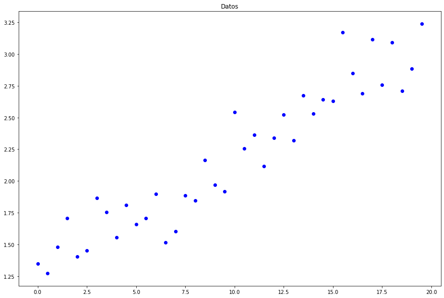

```python
import numpy as np #Librería numérica
import matplotlib.pyplot as plt # Para crear gráficos con matplotlib
#%matplotlib inline # Si quieres hacer estos gráficos dentro de un jupyter notebook

from sklearn.linear_model import LinearRegression #Regresión Lineal con scikit-learn

def f(x):  # función f(x) = 0.1*x + 1.25 + 0.2*Ruido_Gaussiano
    np.random.seed(42) # para poder reproducirlo
    y = 0.1*x + 1.25 + 0.2*np.random.randn(x.shape[0])
    return y

x = np.arange(0, 20, 0.5) # generamos valores x de 0 a 20 en intervalos de 0.5
y = f(x) # calculamos y a partir de la función que hemos generado

# hacemos un gráfico de los datos que hemos generado
plt.figure(figsize=(15,10))
plt.scatter(x,y,label='data', color='blue')
plt.title('Datos');
```

## Proceso de entrenamiento del modelo de Regresión lineal

```python
# Importamos la clase de Regresión Lineal de scikit-learn
from sklearn.linear_model import LinearRegression

regresion_lineal = LinearRegression() # creamos una instancia de LinearRegression

# instruimos a la regresión lineal que aprenda de los datos (x,y)
regresion_lineal.fit(x.reshape(-1,1), y)

# vemos los parámetros que ha estimado la regresión lineal
print('w = ' + str(regresion_lineal.coef_) + ', b = ' + str(regresion_lineal.intercept_))

# resultado: w = [0.09183522], b = 1.2858792525736682
```

```
w = [0.09183522], b = 1.2858792525736682
```

## Una vez entrando el modelo, obtenemos los valores de ordenada al origen y pendiente de la recta que menor error tienen para cada punto del universo del proceso.

Con dichos valores podremos predecir el valor de y para cualquier x.

```python
# vamos a predicir y = regresion_lineal(5)
nuevo_x = np.array([5])
prediccion = regresion_lineal.predict(nuevo_x.reshape(-1,1))

print(prediccion)

# resultado: [1.7449]
```

```
[1.74505534]
```

```python
# importamos el cálculo del error cuadrático medio (MSE)
from sklearn.metrics import mean_squared_error

# Predecimos los valores y para los datos usados en el entrenamiento
prediccion_entrenamiento = regresion_lineal.predict(x.reshape(-1,1))

# Calculamos el Error Cuadrático Medio (MSE = Mean Squared Error)
mse = mean_squared_error(y_true = y, y_pred = prediccion_entrenamiento)

# La raíz cuadrada del MSE es el RMSE
rmse = np.sqrt(mse)

print('Error Cuadrático Medio (MSE) = ' + str(mse))
print('Raíz del Error Cuadrático Medio (RMSE) = ' + str(rmse))
```

```
Error Cuadrático Medio (MSE) = 0.03318522012927899
Raíz del Error Cuadrático Medio (RMSE) = 0.18216810952875093
```

# Función polinómica de 3 grado sumado un error aleatorio.

Esta función podría representar la mejor alternativa en un calculo de regresión en la que los datos obtenidos necesitan ser ajustados con un error menor.

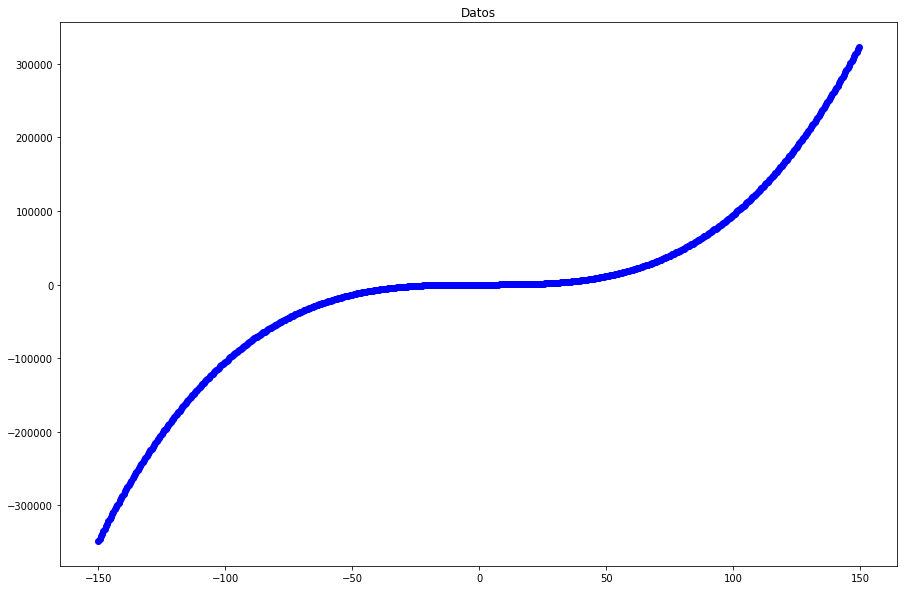

```python
import numpy as np #Librería numérica
import matplotlib.pyplot as plt # Para crear gráficos con matplotlib
#%matplotlib inline # Si quieres hacer estos gráficos dentro de un jupyter notebook

from sklearn.linear_model import LinearRegression #Regresión Lineal con scikit-learn

def f(x):  # función f(x) = 0.1*x + 1.25 + 0.2*Ruido_Gaussiano
    np.random.seed(42) # para poder reproducirlo
    y = -10 - 0.5*x**2 + 0.10*x**3 + 0.2*np.random.randn(x.shape[0])
    return y

x = np.arange(-150, 150, 0.5) # generamos valores x de 0 a 20 en intervalos de 0.5
y = f(x) # calculamos y a partir de la función que hemos generado

# hacemos un gráfico de los datos que hemos generado
plt.figure(figsize=(15,10))
plt.scatter(x,y,label='data', color='blue')
plt.title('Datos');
```

## La función de la distribución normal es la que se observa a continuación.

Esta función es esencial en probabilidad y estadística.

https://es.wikipedia.org/wiki/Distribución_normal

### $ \eta_{(\mu,\sigma)}(x) = \frac{1}{\sqrt{2 \pi} \sigma} e^{-\frac{1}{2} \large(\frac{(x-\mu)}{\sigma})^{2}} ; x \in \mathbb{R} $ La función de distribución normal estándar es un caso especial de la función donde $\mu = 0 ; \sigma = 1 $

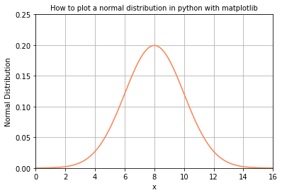

```python
import matplotlib.pyplot as plt
import scipy.stats
import numpy as np

x_min = 0.0
x_max = 16.0

mean = 8.0
std = 2.0

x = np.linspace(x_min, x_max, 100)
y = scipy.stats.norm.pdf(x,mean,std)
plt.plot(x,y, color='coral')
plt.grid()
plt.xlim(x_min,x_max)
plt.ylim(0,0.25)
plt.title('How to plot a normal distribution in python with matplotlib',fontsize=10)
plt.xlabel('x')
plt.ylabel('Normal Distribution')
plt.savefig("normal_distribution.png")
plt.show()
```